# Gapminder-MPG-Data-Visualisation

AUGUSTINE KWABENA OSEI-FOSU

Monday, February 11, 2019

## Life expectancy in 2007

```r
# Notice the warning=FALSE and message=FALSE in the chunk options. R spits out
# a lot of messages when you load tidyverse and we don't want those in the
# final document.

library(tidyverse)  # This loads ggplot2, dplyr, and other packages you'll need
library(gapminder)  # This loads the gapminder data
```

Let’s first look at the first few rows of data:

```r
head(gapminder)
```

| country | continent | year | lifeExp | pop | gdpPercap |
| --- | --- | --- | --- | --- | --- |
| Afghanistan | Asia | 1952 | 28.801 | 8425333 | 779.4453 |
| Afghanistan | Asia | 1957 | 30.332 | 9240934 | 820.8530 |
| Afghanistan | Asia | 1962 | 31.997 | 10267083 | 853.1007 |
| Afghanistan | Asia | 1967 | 34.020 | 11537966 | 836.1971 |
| Afghanistan | Asia | 1972 | 36.088 | 13079460 | 739.9811 |
| Afghanistan | Asia | 1977 | 38.438 | 14880372 | 786.1134 |

Right now, the `gapminder` data frame contains rows for all years for all countries. We want to only look at 2007, so we create a new data frame that filters only rows for 2007.

Note how there’s a weird sequence of characters: `%>%`. This is called a *pipe* and lets you chain functions together. We could have also written this as `gapminder_2007 <- filter(gapminder, year == 2007)`.

```r
gapminder_2007 <- gapminder %>%
  filter(year == 2007)

head(gapminder_2007)
```

| country | continent | year | lifeExp | pop | gdpPercap |
| --- | --- | --- | --- | --- | --- |
| Afghanistan | Asia | 2007 | 43.828 | 31889923 | 974.5803 |
| Albania | Europe | 2007 | 76.423 | 3600523 | 5937.0295 |
| Algeria | Africa | 2007 | 72.301 | 33333216 | 6223.3675 |
| Angola | Africa | 2007 | 42.731 | 12420476 | 4797.2313 |
| Argentina | Americas | 2007 | 75.320 | 40301927 | 12779.3796 |
| Australia | Oceania | 2007 | 81.235 | 20434176 | 34435.3674 |

Now we can plot a histogram of 2007 life expectancies with the default settings:

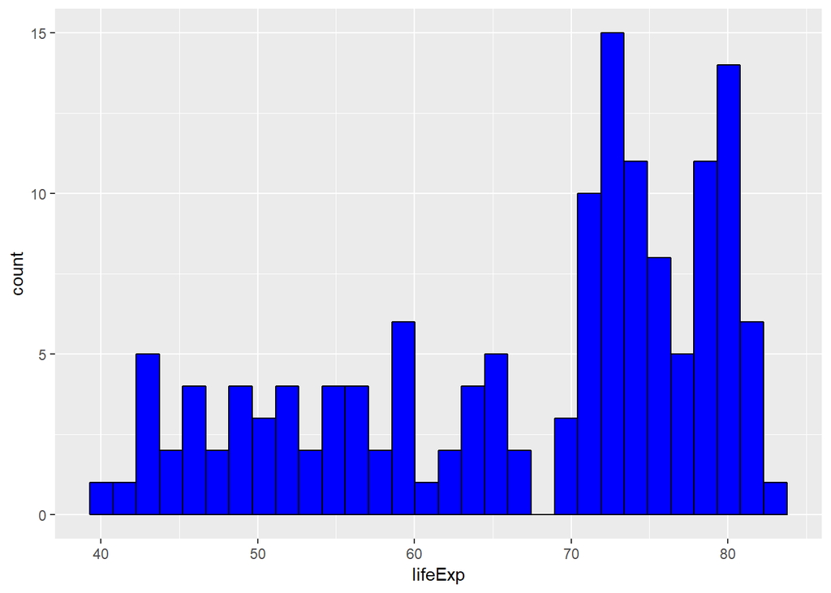

```r
ggplot(data = gapminder_2007,
       mapping = aes(x = lifeExp)) +
  geom_histogram(fill = "blue", color = "black")
```

Of the choices that were suggested to be used, I will say the best was bins of 40, and not because it was the one closer to the default suggested by R but of the three suggestions, it is the one that gives the picture of the distribution. Bins of 2 seems to merge everything together that one will not get a clear appreciation of the distribution while bins of 100 seem to over details the distribution. But left with me alone in this example I will still keep the default suggestion.

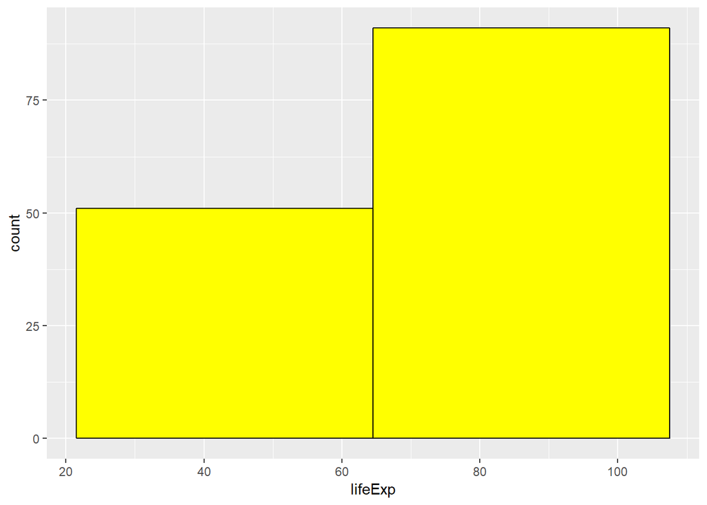

```r
ggplot(data = gapminder_2007,
       mapping = aes(x = lifeExp)) +
  geom_histogram(bins = 2, fill = "Yellow", color = "black")
```

## Average life expectancy in 2007 by continent

We’re also interested in the differences of life expectancy across continents. First, we can group all rows by continent and calculate the mean

This is where the `%>%` function is actually super useful. Remember that it lets you chain functions togetherâthis means we can read these commands as a set of instructions: take the `gapminder` data frame, filter it, group it by continent, and summarize each group by calculating the mean. Without using the `%>%`, we could write this same chain like this: `summarize(group_by(filter(gapminder, year == 2007), continent), avg_life_exp = mean(lifeExp))`. But that’s *awful* and impossible to read and full of parentheses that can easily be mismatched.

```r
gapminder_cont_2007 <- gapminder %>%
  filter(year == 2007) %>%
  group_by(continent) %>%
  summarize(avg_life_exp = mean(lifeExp))

head(gapminder_cont_2007)
```

| continent | avg_life_exp |
| --- | --- |
| Africa | 54.80604 |
| Americas | 73.60812 |
| Asia | 70.72848 |
| Europe | 77.64860 |
| Oceania | 80.71950 |

Let’s plot these averages as a bar chart:

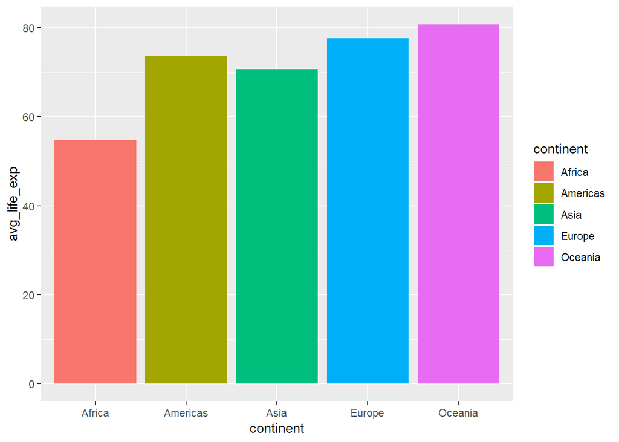

```r
ggplot(data = gapminder_cont_2007,
       mapping = aes(x = continent, y = avg_life_exp, fill = continent)) +
  geom_col()
```

Then, let’s plot them as density distributions. We don’t need to use the summarized data frame for this, just the original filtered `gapminder_2007` data frame:

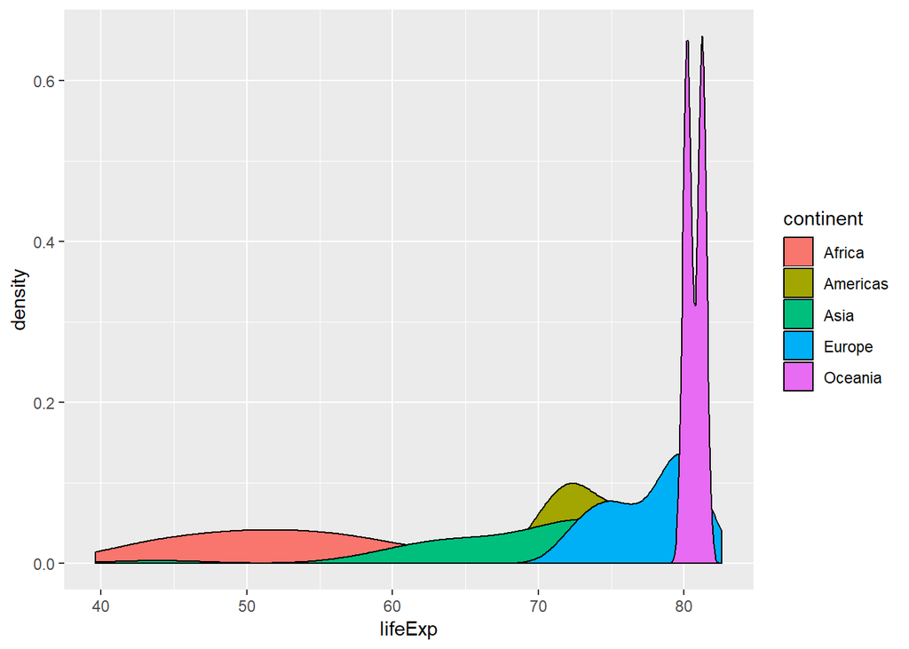

```r
ggplot(data = gapminder_2007,
       mapping = aes(x = lifeExp, fill = continent)) +
  geom_density()
```

Now let’s plot life expectancies as violin charts. These are the density distributions turned sideways:

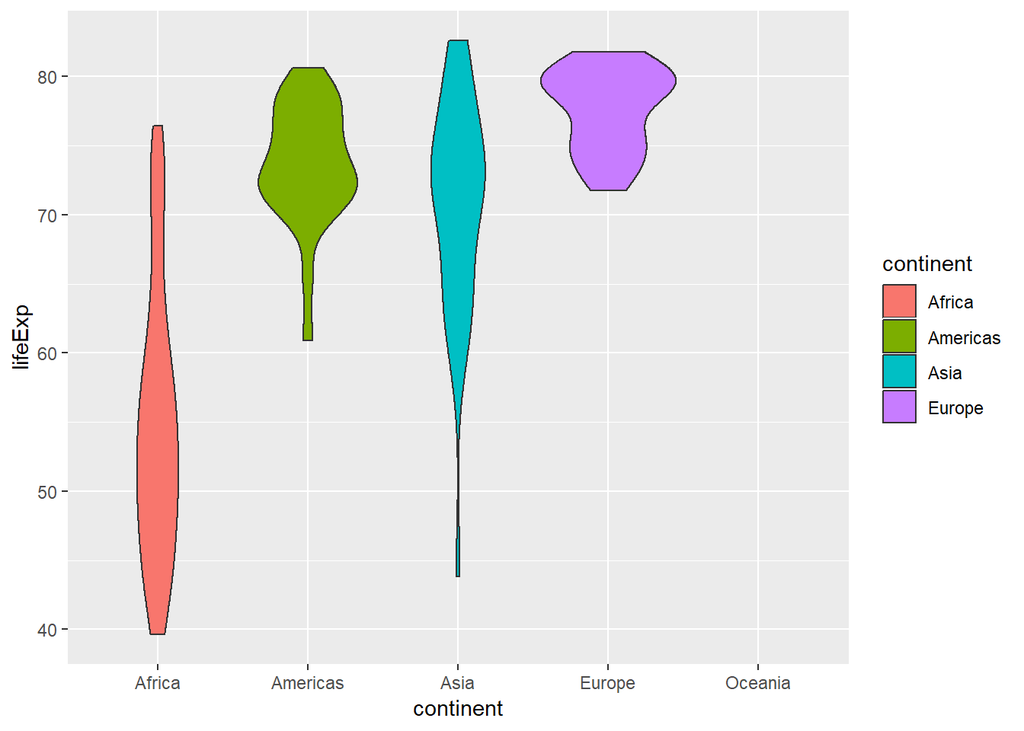

```r
ggplot(data = gapminder_2007,
       mapping = aes(x = continent, y = lifeExp, fill = continent)) +
  geom_violin()
```

Finally, we can add actual points of data for each country to the violin chart:

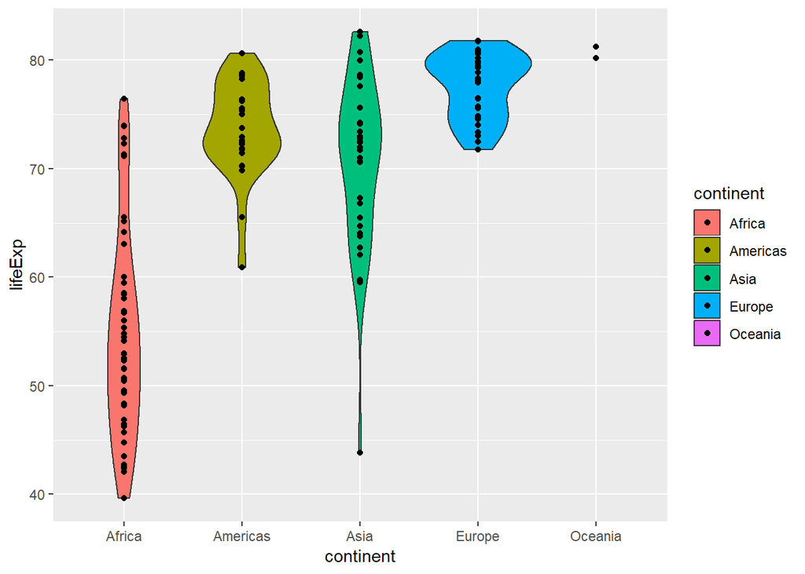

```r
ggplot(data = gapminder_2007,
       mapping = aes(x = continent, y = lifeExp, fill = continent)) +
  geom_violin() +
  geom_point()
```

The bar chart, density plot, violin plot, and violin plot + points each show different ways of looking at a single numberâthe average life expectancy in each continent.

The most helpful, I will say the bar chart. The reason for my choice will be the ideal of familiarity

Obviously, it is a context between the last three but I will choose violin point since it does not even present Oceania on the chart.

```r
# Technically you don't need to run this because we loaded tidyverse earlier in Task 2
library(tidyverse)
```

## 3.2.4

**1: Run `ggplot(data = mpg)`. What do you see?**

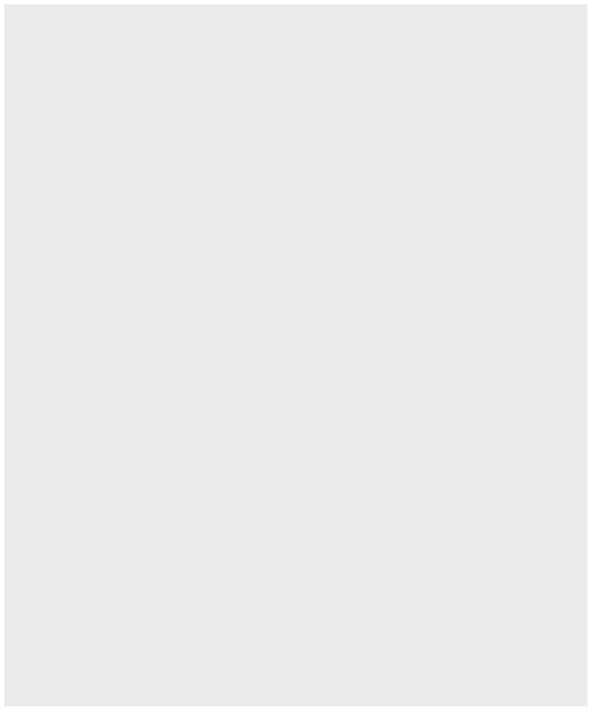

```r
ggplot(data = mpg)
```

ggplot (data = mpg) nothing will be plotted other than an empty sheet

(Notice how I used `fig.width` and `fig.height` in the chunk options. You can click on the little gear icon in the far left of the chunk to change other options.) Yes, It can be changed to any shape, and I did change it to fig.height=12, fig.width=10

**2: How many rows are in `mpg`? How many columns?** There are 11 columns in dataset mpg

```r
nrow(mpg)
```

```
## [1] 234
```

```r
ncol(mpg)
```

```
## [1] 11
```

```r
# Or
dim(mpg)
```

```
## [1] 234  11
```

```r
# Or
mpg
```

| manufacturer | model | displ | year | cyl | trans | drv | cty | hwy | fl | class |
| --- | --- | --- | --- | --- | --- | --- | --- | --- | --- | --- |
| audi | a4 | 1.8 | 1999 | 4 | auto(l5) | f | 18 | 29 | p | compact |
| audi | a4 | 1.8 | 1999 | 4 | manual(m5) | f | 21 | 29 | p | compact |
| audi | a4 | 2.0 | 2008 | 4 | manual(m6) | f | 20 | 31 | p | compact |
| audi | a4 | 2.0 | 2008 | 4 | auto(av) | f | 21 | 30 | p | compact |
| audi | a4 | 2.8 | 1999 | 6 | auto(l5) | f | 16 | 26 | p | compact |
| audi | a4 | 2.8 | 1999 | 6 | manual(m5) | f | 18 | 26 | p | compact |
| audi | a4 | 3.1 | 2008 | 6 | auto(av) | f | 18 | 27 | p | compact |
| audi | a4 quattro | 1.8 | 1999 | 4 | manual(m5) | 4 | 18 | 26 | p | compact |
| audi | a4 quattro | 1.8 | 1999 | 4 | auto(l5) | 4 | 16 | 25 | p | compact |
| audi | a4 quattro | 2.0 | 2008 | 4 | manual(m6) | 4 | 20 | 28 | p | compact |

[output cut: 224 more lines]

**3: What does the `drv` variable describe? Read the help for `?mpg` to find out.**

It is a categorical variable which categorizes the cars into f = front-wheel drive, r = rear wheel drive, 4 = 4wd.

**4: Make a scatterplot of `hwy` vs `cyl`.**

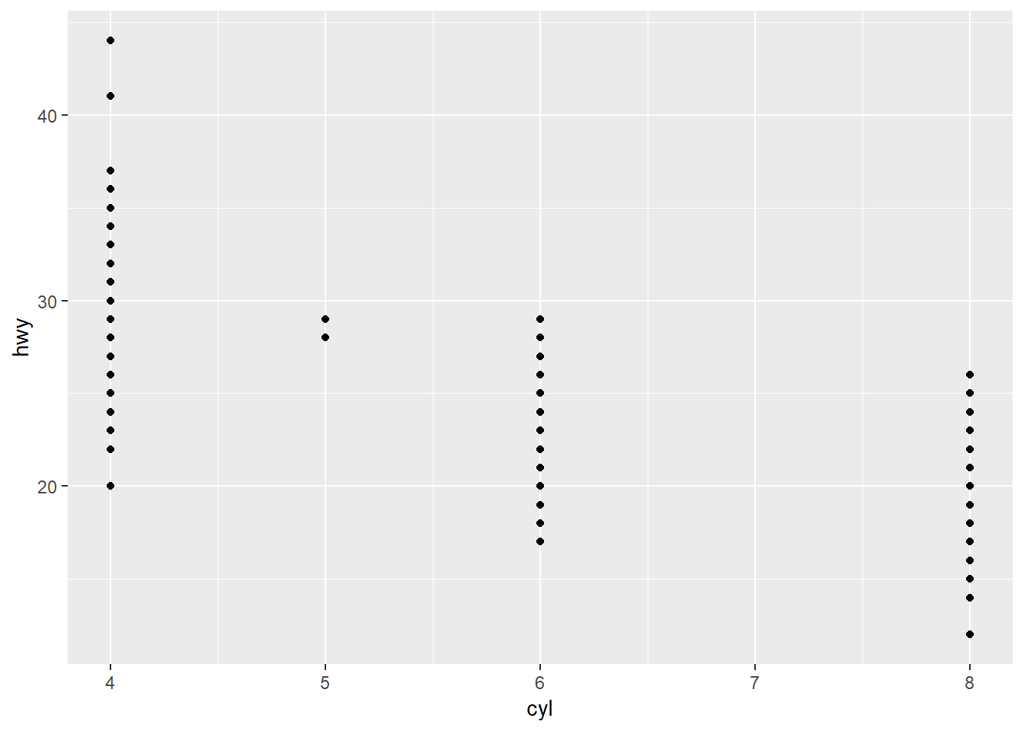

```r
ggplot(data = mpg) +
  geom_point(mapping = aes(x = cyl, y = hwy))
```

**5: What happens if you make a scatterplot of `class` vs `drv`? Why is the plot not useful?**

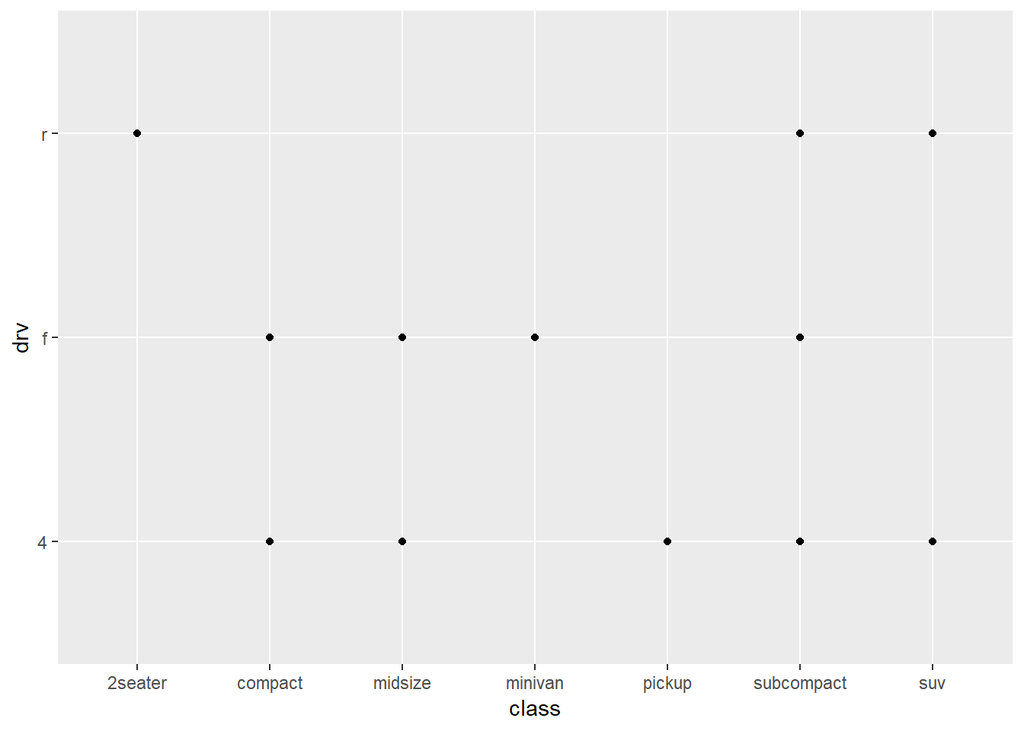

```r
ggplot(data = mpg) +
  geom_point(mapping = aes(x = class, y = drv))
```

Scatter plot, is supposed to depicked the relational effect of two variables. But the class and drv attributes are all categorical hence the plot shows the mapping between these categories.